# 3. Obesity EDA

### Importing necessary libraries

```python
import pandas as pd
import numpy as np
import seaborn as sns
import matplotlib.pyplot as plt
import statsmodels.api as sm

# code to ignore warnings
import warnings
warnings.filterwarnings("ignore")

root_csv = '../csv files/'
root_pickle = '../pickle files/'
```

### Reading Files

```python
df_obese_total_pivot = pd.read_pickle(root_pickle +'Obesity_Total_Pivot.pkl')
df_obese_total_pivot.head(5)
```

|  | State | County | CountyFIPS | Year | Total Absolute | Total Percentage | Grocery Tax | Restaurant Tax | tax_delta | Population |
| --- | --- | --- | --- | --- | --- | --- | --- | --- | --- | --- |
| 0 | Alabama | Autauga County | 1001 | 2004 | 7213.0 | 21.9 | 0.04 | 0.04 | 0.0 | 32936.073633 |
| 6 | Alabama | Autauga County | 1001 | 2005 | 8093.0 | 24.0 | 0.04 | 0.04 | 0.0 | 33720.833333 |
| 12 | Alabama | Autauga County | 1001 | 2006 | 7457.0 | 21.5 | 0.04 | 0.04 | 0.0 | 34683.720930 |
| 18 | Alabama | Autauga County | 1001 | 2007 | 7467.0 | 21.1 | 0.04 | 0.04 | 0.0 | 35388.624953 |
| 24 | Alabama | Autauga County | 1001 | 2008 | 9568.0 | 26.6 | 0.04 | 0.04 | 0.0 | 35969.924296 |

### Exploratory Data Analysis

Before moving to Scatter plot and Pearson Correlation, lets focus only on total numbers and percentage and remove duplicates established due to gender and age:

#### 1. Grocery Tax

##### a. Total Absolute Obesity vs Grocery Tax

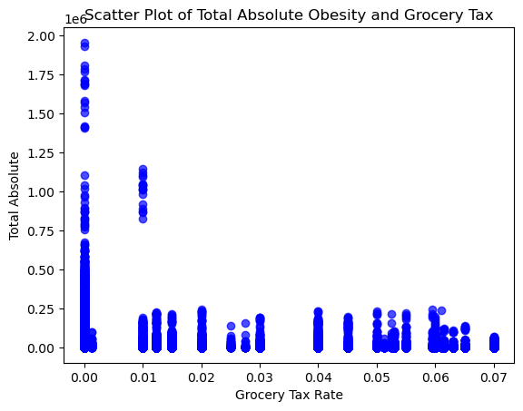

```python
plt.scatter(df_obese_total_pivot['Grocery Tax'], df_obese_total_pivot['Total Absolute'], marker='o', color='blue', alpha=0.7)

# Add labels and title
plt.xlabel('Grocery Tax Rate')
plt.ylabel('Total Absolute')
plt.title('Scatter Plot of Total Absolute Obesity and Grocery Tax')
```

##### Conclusion:

At higher grocery tax rates, the total absolute number is concentrated to lower bandwidth. However, this is not a causation. It is possible that since we are looking at totals, the counties/states with high grocery tax rate have less population and hence less absolute number in Obesity. Hence we will draw a plot on Percentage

##### b. Total Percentage Obesity vs Grocery Tax

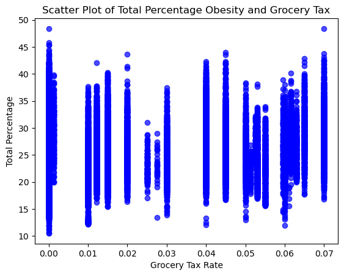

```python
plt.scatter(df_obese_total_pivot['Grocery Tax'], df_obese_total_pivot['Total Percentage'], marker='o', color='blue', alpha=0.7)

# Add labels and title
plt.xlabel('Grocery Tax Rate')
plt.ylabel('Total Percentage')
plt.title('Scatter Plot of Total Percentage Obesity and Grocery Tax')
```

##### Conclusion:

This plot helps us quash the possible causation based on absolute number. Looks like the percentage Obesity is not much influenced by grocery tax. Lets do a Pearson correlation test to understand more.

##### c. Pearson Correlation of Total Absolute with Grocery Tax

```python
correlation = df_obese_total_pivot['Grocery Tax'].corr(df_obese_total_pivot['Total Absolute'])
print('Grocery Tax - Total Absolute ',correlation)
```

```
Grocery Tax - Total Absolute  -0.092495671438545
```

##### Conclusion:

This correlation shows that total absolute has negative correlation with grocery tax i.e. as grocery tax increases the total absolute number decreases. However, this is again on absolute numbers and does not account for population number. Hence we will do a Pearson Correlation on Percentage.

##### d. Pearson Correlation of Total Percentage with Grocery Tax

```python
correlation = df_obese_total_pivot['Grocery Tax'].corr(df_obese_total_pivot['Total Percentage'])
print('Grocery Tax - Total Percentage',correlation)
```

```
Grocery Tax - Total Percentage 0.07356001522293464
```

##### Conclusion:

This correlation shows that total percentage has a minor positive correlation with grocery tax i.e. as grocery tax increases the total percentage of Obesity patient increases.

#### 2. Restaurant Tax

##### a. Total Absolute Obesity vs Restaurant Tax

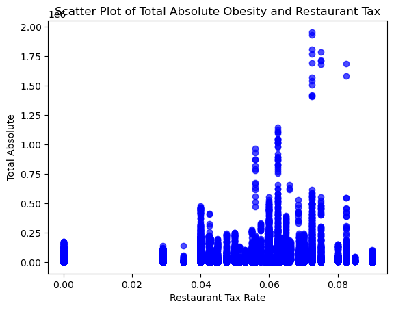

```python
plt.scatter(df_obese_total_pivot['Restaurant Tax'], df_obese_total_pivot['Total Absolute'], marker='o', color='blue', alpha=0.7)

# Add labels and title
plt.xlabel('Restaurant Tax Rate')
plt.ylabel('Total Absolute')
plt.title('Scatter Plot of Total Absolute Obesity and Restaurant Tax')
```

##### Conclusion:

At lower restaurant tax rates, the total absolute number is concentrated to lower bandwidth. However, this is not a causation. It is possible that since we are looking at totals, the counties/states with lower restaurant tax rate have less population and hence less absolute number in Obesity. Hence we will draw a plot on Percentage

##### b. Total Percentage Obesity vs Restaurant Tax

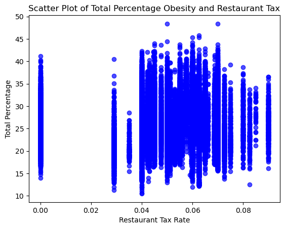

```python
plt.scatter(df_obese_total_pivot['Restaurant Tax'], df_obese_total_pivot['Total Percentage'], marker='o', color='blue', alpha=0.7)

# Add labels and title
plt.xlabel('Restaurant Tax Rate')
plt.ylabel('Total Percentage')
plt.title('Scatter Plot of Total Percentage Obesity and Restaurant Tax')
```

##### Conclusion:

This plot helps us quash the possible causation based on absolute number. Looks like the percentage Obesity is not much influenced by restaurant tax. Lets do a Pearson correlation test to understand more.

##### c. Pearson Correlation of Total Absolute with Restaurant Tax

```python
correlation = df_obese_total_pivot['Restaurant Tax'].corr(df_obese_total_pivot['Total Absolute'])
print('Restaurant Tax - Total Absolute ',correlation)
```

```
Restaurant Tax - Total Absolute  0.07486611677535743
```

##### Conclusion:

This correlation shows that total absolute has slight positive correlation with restaurant tax i.e. as restaurant tax increases the total absolute number increases. However, this is again on absolute numbers and does not account for population number. Hence we will do a Pearson Correlation on Percentage.

##### d. Pearson Correlation of Total Percentage with Restaurant Tax

```python
correlation = df_obese_total_pivot['Restaurant Tax'].corr(df_obese_total_pivot['Total Percentage'])
print('Restaurant Tax - Total Percentage',correlation)
```

```
Restaurant Tax - Total Percentage 0.06514626837736225
```

##### Conclusion:

This correlation shows that total percentage has a minor positive correlation with restaurant tax i.e. as restaurant tax increases the total percentage of Obesity patient increases.